# 03_A_TSGraphs_Timeplots_Scatterplots_Seasonalplots

# Libraries

```r
library(fpp3)
library(fma)
library(readr)
```

# References

This is not original material but a compilation of the following sources with some additional examples and clarifications introduced by the professor:

1. Hyndman, R.J., & Athanasopoulos, G., 2021. *Forecasting: principles and practice*. 3rd edition.
2. Additional material provided by the book authors
3. The Datasaurus Dozen - [Link](https://blog.revolutionanalytics.com/2017/05/the-datasaurus-dozen.html)
4. Shumway, R.; Stoffer, D; *Time Series Analysis and Its Applications with R examples*.

# Framework and packages:

We will work with the fpp3 package, developed by Prof. Rob Hyndman and his team, one of the leading research groups in time series analysis.

This package extends the tidyverse framework to time series. To do so it loads several packages under the hood (see the output of the following cell):

```r
library(fpp3)
```

Additionally, for this session we will use the packages `GGally`, `fma` and `patchwork`. Load them with the `library` command. You must do this every time you restart your R session.

```r
library(patchwork) # Used to manage the relative location of ggplots
library(GGally)
library(fma) # to load the Us treasury bills dataset
```

# Time plots and basic time series patterns

Time series patterns

| Pattern | Description |
| --- | --- |
| Trend | Long-term increase OR decrease in the data |
| Seasonal | Periodic pattern due to the calendar (quarter, month, day of the week...) |
| Cyclic | Pattern where data exhibits rises and falls that are NOT FIXED IN PERIOD (typically duration of at least 2 years) |

Seasonal or cyclic

| Seasonal | Cyclic |
| --- | --- |
| Seasonal pattern of constant length | Cyclic patern of variable length |
| Shorter than cyclic pattern | Longer than periodic pattern |
| Magnitude less variable than cyclic pattern | Magnitude more variable than periodic pattern |

Let us look at some examples:

## Example 1 - trended and seasonal data

### `scale_x_yearquarter`: adjusting the grid when the time index is a `yearquarter` object

Inspecting the dataset `aus_production`, we note two things:

1. Like all datasets loaded with the `fpp3` package, it comes in `tsibble` format.
2. The column that signals time (the index of the tsibble) is of type `yearquarter`.

```r
aus_production
```

```
# A tsibble: 218 x 7 [1Q]
   Quarter  Beer Tobacco Bricks Cement Electricity   Gas
     <qtr> <dbl>   <dbl>  <dbl>  <dbl>       <dbl> <dbl>
 1 1956 Q1   284    5225    189    465        3923     5
 2 1956 Q2   213    5178    204    532        4436     6
 3 1956 Q3   227    5297    208    561        4806     7
 4 1956 Q4   308    5681    197    570        4418     6
 5 1957 Q1   262    5577    187    529        4339     5
 6 1957 Q2   228    5651    214    604        4811     7
 7 1957 Q3   236    5317    227    603        5259     7
 8 1957 Q4   320    6152    222    582        4735     6
 9 1958 Q1   272    5758    199    554        4608     5
10 1958 Q2   233    5641    229    620        5196     7
# ℹ 208 more rows
```

**Because the index of the tsibble is of type `yearquarter`**, we use the function **`scale_x_yearquarter`** to scale the x-axis of the time plot below.

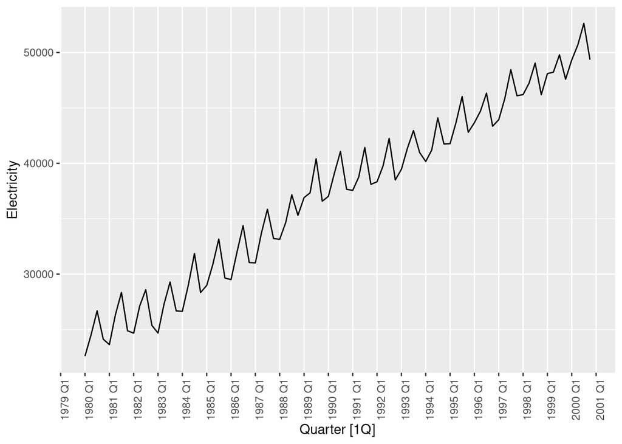

```r
aus_production |>

  # Filter data to show appropriate timeframe
  filter((year(Quarter) >= 1980 & year(Quarter)<= 2000)) |>

  # autoplot generates a simple time plot, to be adjusted with
  # further commands.
  autoplot(Electricity) +

  # Scale the x axis adequately
  # scale_x_yearquarter used because the index is a yearquarter column
  scale_x_yearquarter(date_breaks = "1 year",
                      minor_breaks = "1 year") +

  # Flip x-labels by 90 degrees
  theme(axis.text.x = element_text(angle = 90))
```

Strong trend with a change in the slope of the trend around 1990.

### `autoplot()` as a wrapper around ggplot2 objects

The `autoplot()` function from the `fpp3` package is a wrapper around ggplot2 objects. Depending on the object passed to it, it behaves differently, combining different ggplot components.

In the example above, `autoplot()` receives a time series in tsibble format, so it acts as a wrapper around the ggplot command `geom_line()`. Using `autoplot()` is more convenient than building the ggplot call by hand, which is why a dedicated time series package like `fpp3` provides it. The code below spells out the ggplot commands explicitly and produces the same output as `autoplot`.

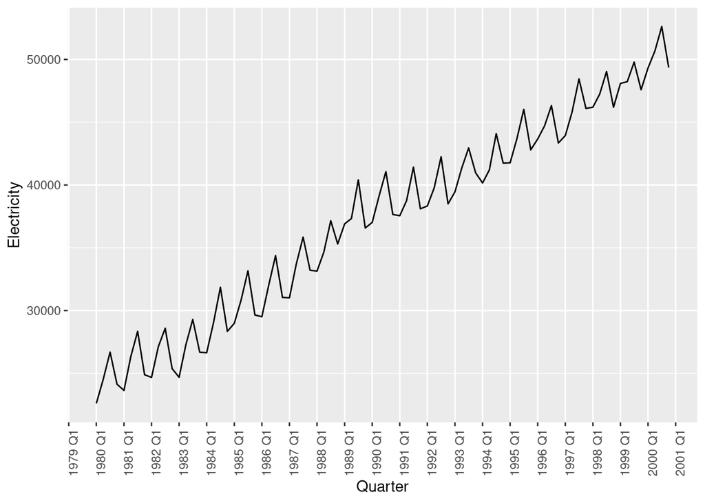

```r
aus_production |>

  filter((year(Quarter) >= 1980 & year(Quarter)<= 2000)) |>

  # The two lines below are equivalent to autoplot(Electricity)
  ggplot(aes(x = Quarter, y = Electricity)) +
  geom_line() +

  # Scale the x axis adequately
  # scale_x_yearquarter used because the index is a yearquarter column
  scale_x_yearquarter(date_breaks = "1 year",
                      minor_breaks = "1 year") +

  # Flip x-labels by 90 degrees
  theme(axis.text.x = element_text(angle = 90))
```

## Example 2 - **exercise** - trended and seasonal data with recessions

Scale the x-grid so that more years can be identified on the plot, but avoid crowding the labels too much.

**Hint:** remember to use the scaling function that is congruent with the tsibble’s index (frequency).

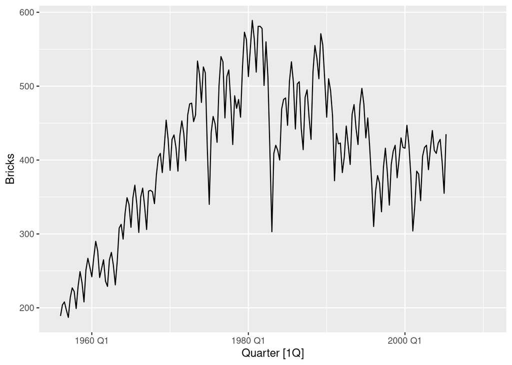

```r
aus_production |>
  autoplot(Bricks)
```

### We’ll discuss potential solutions during the live session.

## Example 3 - trend embedded within a cycle

US Treasury bill contracts on the Chicago market for 100 consecutive trading days in 1981.

See [Treasury Bills](https://www.investopedia.com/terms/t/treasurybill.asp).

The `ustreas` object is loaded with the `fma` package, which we loaded at the start of the notebook.

```r
ustreas
```

```
Time Series:
Start = 1
End = 100
Frequency = 1
  [1] 91.57 91.56 91.40 91.39 91.20 90.90 90.99 91.17 90.98 91.11 91.20 90.92
 [13] 90.73 90.79 90.86 90.83 90.80 90.21 90.10 90.10 89.66 89.81 89.40 89.34
 [25] 89.16 88.71 89.28 89.36 89.64 89.53 89.32 89.14 89.41 89.53 89.16 88.98
 [37] 88.50 88.63 88.62 88.76 89.07 88.47 88.41 88.57 88.23 87.93 87.88 88.18
 [49] 88.04 88.18 88.78 89.29 89.14 89.14 89.42 89.26 89.37 89.51 89.66 89.39
 [61] 89.02 89.05 88.97 88.57 88.44 88.52 87.92 87.71 87.52 87.37 87.27 87.07
 [73] 86.83 86.88 87.48 87.30 87.87 87.85 87.83 87.40 86.89 87.38 87.48 87.21
 [85] 87.02 87.10 87.02 87.07 86.74 86.35 86.32 86.77 86.77 86.49 86.02 85.52
 [97] 85.02 84.42 85.29 85.32
```

`ustreas` is a `ts` object (time series). This is another possible format for time series in R, but we will use `tsibble`s to work seamlessly with the fpp3 package. You can convert the `ts` object to a `tsibble` with `as_tsibble` as follows:

```r
ustreas_tsibble <- as_tsibble(ustreas)
ustreas_tsibble
```

```
# A tsibble: 100 x 2 [1]
   index value
   <dbl> <dbl>
 1     1  91.6
 2     2  91.6
 3     3  91.4
 4     4  91.4
 5     5  91.2
 6     6  90.9
 7     7  91.0
 8     8  91.2
 9     9  91.0
10    10  91.1
# ℹ 90 more rows
```

```
Plot variable not specified, automatically selected `.vars = value`
```

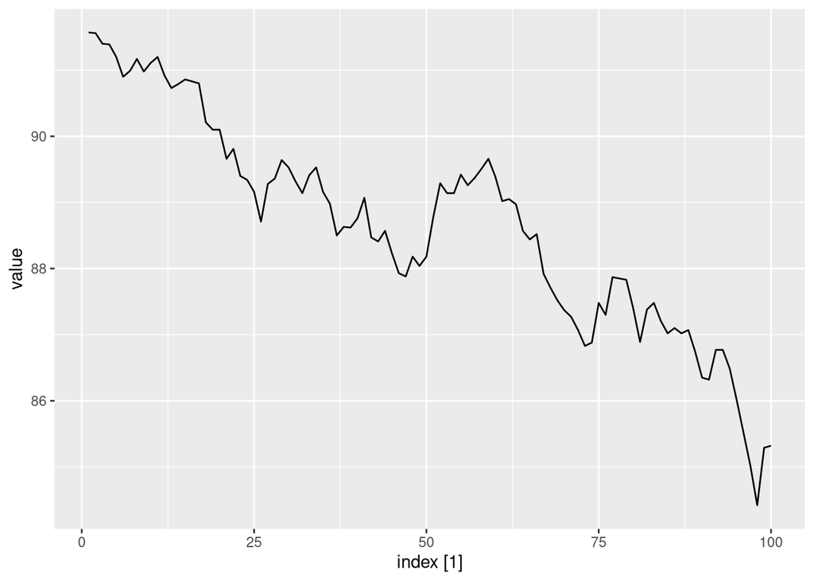

```r
autoplot(ustreas_tsibble)
```

This looks like a downward trend, but it is part of a much longer cycle that is not shown. Do not use this data to forecast too far into the future (the forecast will be reasonable for a few days and then wrong, because the cycle will eventually turn and the model has no mechanism to capture that having never “seen” a turn in this time window of just 100 days).

### `scale_x_continuous`: adjusting the grid when the index is numeric.

Inspecting the tsibble `ustreas_tsibble` shows that **the index is numeric (trading day)**, of type `dbl` (double-precision floating point).

```r
ustreas_tsibble |> head(5)
```

```
# A tsibble: 5 x 2 [1]
  index value
  <dbl> <dbl>
1     1  91.6
2     2  91.6
3     3  91.4
4     4  91.4
5     5  91.2
```

When the index is numeric, we use `scale_x_continuous` to adjust the x-axis. We also need a sequence that defines the tick positions. For example, for major ticks every 10 days and minor ticks every 5 days:

```r
# Sequence for major ticks, from 0 to the maximum index in the data
major_ticks_seq = seq(0, max(ustreas_tsibble$index), 10)
major_ticks_seq
```

```
 [1]   0  10  20  30  40  50  60  70  80  90 100
```

```r
# Sequence for minor ticks, from 0 to the maximum index in the data
minor_ticks_seq = seq(0, max(ustreas_tsibble$index), 5)
minor_ticks_seq
```

```
 [1]   0   5  10  15  20  25  30  35  40  45  50  55  60  65  70  75  80  85  90
[20]  95 100
```

```
Plot variable not specified, automatically selected `.vars = value`
```

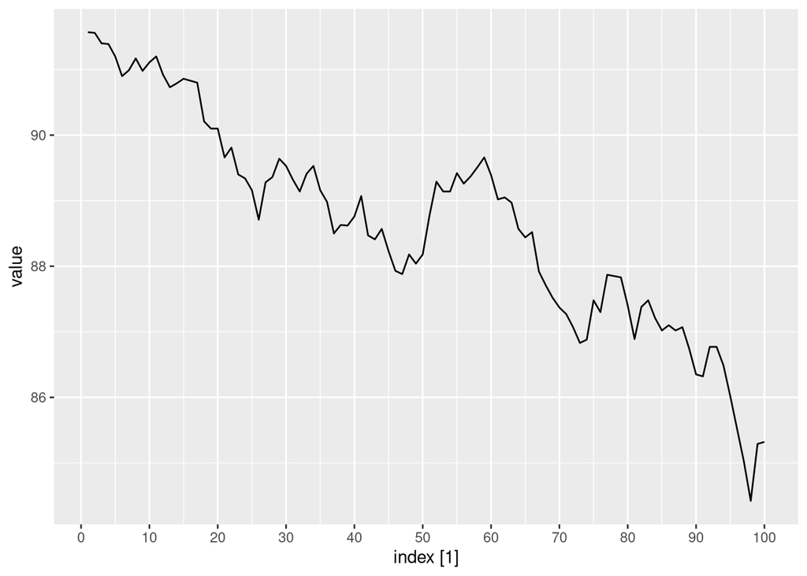

```r
ustreas_tsibble |>
  autoplot() +
  scale_x_continuous(breaks = major_ticks_seq,
                     minor_breaks = minor_ticks_seq)
```

## Example 4 - **exercise**. Yearly data and cyclic behavior

**Annual data** is not susceptible to within-year calendar periods (so-called “seasonal periods”). It is sampled at the same point every year, so within-year calendar periods do not affect it.

In other words: **there are no seasonal patterns in yearly data**. If anything, **there could be cyclic behavior**.

The Hudson Bay Company kept trading records for Snowshoe Hare and Canadian Lynx furs from 1845 to 1935. We are going to analyze the number of Canadian Lynx pelts traded.

```r
pelt |> head(5)
```

```
# A tsibble: 5 x 3 [1Y]
   Year  Hare  Lynx
  <dbl> <dbl> <dbl>
1  1845 19580 30090
2  1846 19600 45150
3  1847 19610 49150
4  1848 11990 39520
5  1849 28040 21230
```

```r
lynx <- pelt |> select(Year, Lynx)
lynx |> head(5)
```

```
# A tsibble: 5 x 2 [1Y]
   Year  Lynx
  <dbl> <dbl>
1  1845 30090
2  1846 45150
3  1847 49150
4  1848 39520
5  1849 21230
```

### Exercise

Plot the time series ensuring we have major ticks every 10 years and minor ticks every 5 years.

**Reminder:** check the type of the index to select the correct function from the `scale_x_*()` family to scale the x-axis.

#### We’ll discuss potential solutions during the live session.

## Example 5 - exercise - Cyclic + seasonal behavior

Monthly sales of new one-family houses sold in the USA since 1973.

The `ts` object `hsales` is loaded with the `fma` package.

```r
hsales_ts <- hsales |> as_tsibble()
```

**Create a time plot that has major ticks every 5 years and minor ticks every year**

### We’ll discuss potential solutions during the live session.

## Example 6 - multiple seasonality

Half-hourly electricity demand in England and Wales from Monday 5 June 2000 to Sunday 27 August 2000. Discussed in Taylor (2003) and kindly provided by James W. Taylor. Units: megawatts.

The `taylor` object is again a time-series object (`ts`).

```r
class(taylor)
```

```
[1] "msts" "ts"
```

However, because the series is sampled every half hour (so we are dealing with date-time data), using `as_tsibble()` directly does not convert this time series to a tsibble correctly:

```r
# Column index represented as a double! This is not what we want.
taylor |> as_tsibble()
```

```
# A tsibble: 4,032 x 2 [9.99999999605049e-07]
   index value
   <dbl> <dbl>
 1  1    22262
 2  1.00 21756
 3  1.01 22247
 4  1.01 22759
 5  1.01 22549
 6  1.01 22313
 7  1.02 22128
 8  1.02 21860
 9  1.02 21751
10  1.03 21336
# ℹ 4,022 more rows
```

To convert the `taylor` `ts` object to a `tsibble`, we define a sequence of date-time objects that matches the length of the `taylor` object. Based on the description, and assuming the measurements on 5 June 2000 start at midnight, the code below turns the `ts` object into a tsibble. You do not need to understand this code in full, but it is explained in detail:

```r
# Define the start time based on information about the Taylor series
# Assume UTC time.
start_time <- as.POSIXct("2000-06-05 00:00:00", tz = "UTC")

# We set by = 1800 because the smallest unit in the date-time object
# start_time is seconds (hh:mm:ss). The samples in this ts object are taken
# every half hour, that is, every 1800 seconds (30 * 60).
# We also set the sequence to the same length as the taylor object.
datetime_seq <- start_time + seq(from = 0, by = 1800, length.out = length(taylor))

# Convert the time series to a tsibble
taylor_ts <-
  tibble(
    index = datetime_seq,
    value = as.numeric(taylor)
  ) |>
  as_tsibble(index = index)

# Check the resulting tsibble
taylor_ts
```

```
# A tsibble: 4,032 x 2 [30m] <UTC>
   index               value
   <dttm>              <dbl>
 1 2000-06-05 00:00:00 22262
 2 2000-06-05 00:30:00 21756
 3 2000-06-05 01:00:00 22247
 4 2000-06-05 01:30:00 22759
 5 2000-06-05 02:00:00 22549
 6 2000-06-05 02:30:00 22313
 7 2000-06-05 03:00:00 22128
 8 2000-06-05 03:30:00 21860
 9 2000-06-05 04:00:00 21751
10 2000-06-05 04:30:00 21336
# ℹ 4,022 more rows
```

Now let us create a quick plot of this object:

```
Plot variable not specified, automatically selected `.vars = value`
```

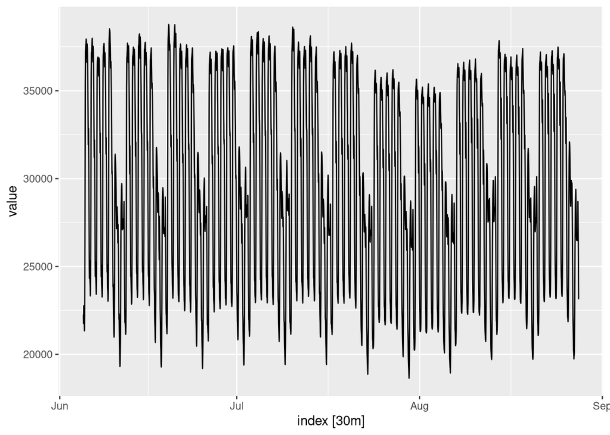

```r
autoplot(taylor_ts)
```

- Two types of seasonality
  - Daily pattern
  - Weekly pattern
- If we had data over a few years, we would see an annual pattern.
- If we had data over a few decades: we might see a longer cyclic pattern

To inspect these patterns more closely, we filter for the first four weeks of the time series. To do this, we create an auxiliary week column and then filter on it:

```
Plot variable not specified, automatically selected `.vars = value`
```

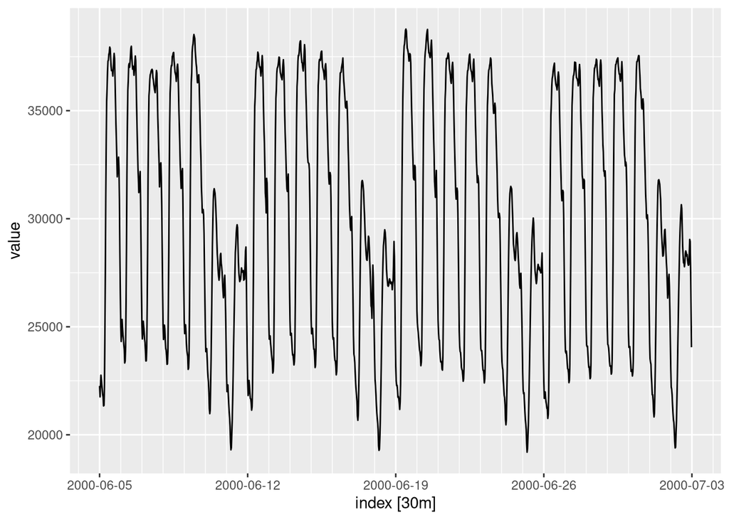

```r
# Create an auxiliary column with the yearweek corresponding to
# each point in the time series.
taylor_ts <-
  taylor_ts |>
  mutate(
    week = yearweek(index)
  )

# Extract first week and compute 4th week
week1 <- taylor_ts$week[1]
week4 <- week1 + 3

# Filter for first four weeks and store in new object
taylor_ts_4w <-
  taylor_ts |>
    filter(
      week >= week1,
      week <= week4
    )

# Show the result
taylor_ts_4w |>

  autoplot() +

  # Used because index is date-time
  scale_x_datetime(
    breaks = "1 week",
    minor_breaks = "1 day"
  )
```

Here we can see the patterns more closely.

**Important:** electricity demand does not always follow such a regular pattern. There may be weekly seasonality, but it is not necessarily this regular. See the next example.

## Example 7 - exercise

We will use the dataset `vic_elec` from the `fpp3` package. It provides half-hourly electricity demand for Victoria (Australia).

```r
vic_elec |> head(5)
```

```
# A tsibble: 5 x 5 [30m] <Australia/Melbourne>
  Time                Demand Temperature Date       Holiday
  <dttm>               <dbl>       <dbl> <date>     <lgl>
1 2012-01-01 00:00:00  4383.        21.4 2012-01-01 TRUE
2 2012-01-01 00:30:00  4263.        21.0 2012-01-01 TRUE
3 2012-01-01 01:00:00  4049.        20.7 2012-01-01 TRUE
4 2012-01-01 01:30:00  3878.        20.6 2012-01-01 TRUE
5 2012-01-01 02:00:00  4036.        20.4 2012-01-01 TRUE
```

### `scale_x_datetime`: indices that are date-time objects

Let us filter `vic_elec` to keep only the data points from January 2012:

```r
elec_jan <- vic_elec |>
              mutate(month = yearmonth(Time)) |>
              filter(month == yearmonth("2012 Jan"))
```

**Create a time plot of this data** using `scale_x_datetime` to establish major breaks of 1 week and minor breaks of 1 day.

#### We’ll discuss potential solutions during the live session.

## Example 8 - exercise

### `scale_x_date`: indices that are date objects

Let us first create a daily time series from the previous `elec_jan` (see example 7), using `index_by` to compute the total electricity consumption within each day.

```r
elec_jan_daily <-
  elec_jan |>
    index_by(date = as_date(Time)) |>
    summarize(
      daily_demand = sum(Demand)
    )

# Inspect result
elec_jan_daily
```

```
# A tsibble: 31 x 2 [1D]
   date       daily_demand
   <date>            <dbl>
 1 2012-01-01      222438.
 2 2012-01-02      257965.
 3 2012-01-03      267099.
 4 2012-01-04      222742.
 5 2012-01-05      210585.
 6 2012-01-06      210247.
 7 2012-01-07      202526.
 8 2012-01-08      193413.
 9 2012-01-09      213804.
10 2012-01-10      215020.
# ℹ 21 more rows
```

Now create a time plot with an x-axis resolution that has: major ticks every week and minor ticks every day

#### We’ll discuss potential solutions during the live session.

## Example 9 - Trend + seasonality (multiplicative)

The `PBS` dataset contains monthly Medicare Australia prescription data. We will keep the records for drugs in the `ATC2` category `"A10"` (antidiabetic drugs). For more information, run `?PBS` in the console.

```r
PBS |>
  filter(ATC2 == "A10") |>
  select(Month, Concession, Type, Cost) |>
  summarise(TotalC = sum(Cost)) |>

  # Remove zeroes to the right if we don't need that resolution
  # Notice the -> operator works as well as <-
  mutate(Cost = TotalC / 1e6) -> a10
```

```r
a10 |> head(5)
```

```
# A tsibble: 5 x 3 [1M]
     Month  TotalC  Cost
     <mth>   <dbl> <dbl>
1 1991 Jul 3526591  3.53
2 1991 Aug 3180891  3.18
3 1991 Sep 3252221  3.25
4 1991 Oct 3611003  3.61
5 1991 Nov 3565869  3.57
```

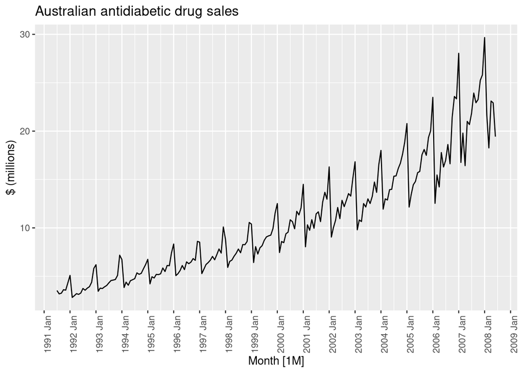

```r
autoplot(a10, Cost) +
  labs(y = "$ (millions)",
       title = "Australian antidiabetic drug sales") +
  scale_x_yearmonth(breaks = "1 year") +
  theme(axis.text.x = element_text(angle = 90))
```

# Scatter plots

## Two variables

The dataset `vic_elec` contains half-hourly data on electricity demand and average temperature in the state of Victoria (Australia).

```r
vic_elec
```

```
# A tsibble: 52,608 x 5 [30m] <Australia/Melbourne>
   Time                Demand Temperature Date       Holiday
   <dttm>               <dbl>       <dbl> <date>     <lgl>
 1 2012-01-01 00:00:00  4383.        21.4 2012-01-01 TRUE
 2 2012-01-01 00:30:00  4263.        21.0 2012-01-01 TRUE
 3 2012-01-01 01:00:00  4049.        20.7 2012-01-01 TRUE
 4 2012-01-01 01:30:00  3878.        20.6 2012-01-01 TRUE
 5 2012-01-01 02:00:00  4036.        20.4 2012-01-01 TRUE
 6 2012-01-01 02:30:00  3866.        20.2 2012-01-01 TRUE
 7 2012-01-01 03:00:00  3694.        20.1 2012-01-01 TRUE
 8 2012-01-01 03:30:00  3562.        19.6 2012-01-01 TRUE
 9 2012-01-01 04:00:00  3433.        19.1 2012-01-01 TRUE
10 2012-01-01 04:30:00  3359.        19.0 2012-01-01 TRUE
# ℹ 52,598 more rows
```

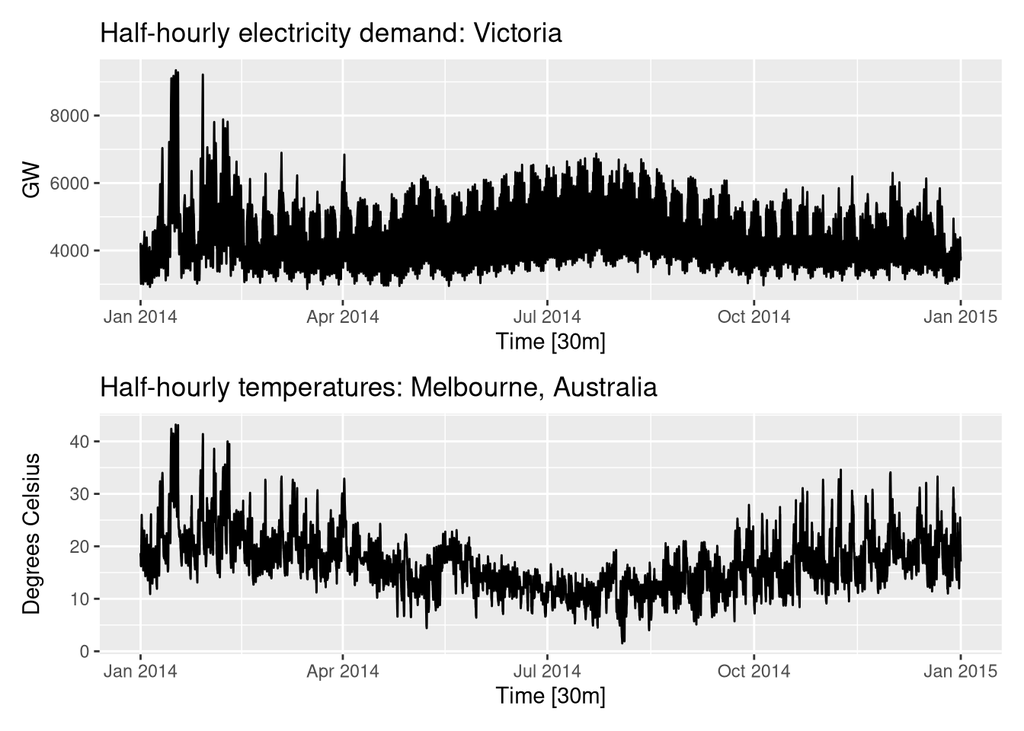

```r
p1 <- vic_elec |>
  filter(year(Time) == 2014) |>
  autoplot(Demand) +
  labs(y = "GW",
       title = "Half-hourly electricity demand: Victoria")

p2 <- vic_elec |>
  filter(year(Time) == 2014) |>
  autoplot(Temperature) +
  labs(
    y = "Degrees Celsius",
    title = "Half-hourly temperatures: Melbourne, Australia"
  )

# Requires GGally. Places one graph above the other, ensuring proper
# matching of the x-axis.
p1 / p2
```

For each point in time, we can now plot the electricity demand against the corresponding average temperature, producing a scatterplot of the two variables instead of a time plot. In this scatterplot we add two trend lines: - A linear trend line following ordinary least squares. - A non-linear trend line following a loess model.

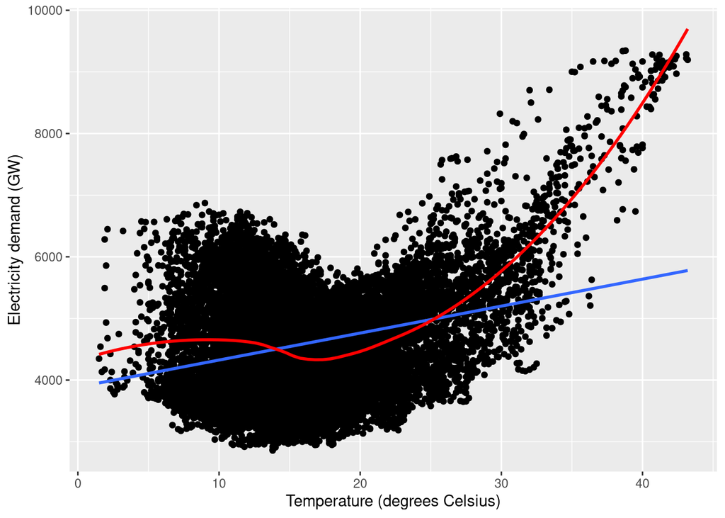

```r
vic_elec |>
  filter(year(Time) == 2014) |>
  ggplot(aes(x = Temperature, y = Demand)) +

  geom_point() +

  # Linear trend line
  geom_smooth(method = "lm", se = FALSE) +

  # Non-linear trend line
  geom_smooth(method = "loess", color = "red", se = FALSE) +

  # Labels
  labs(x = "Temperature (degrees Celsius)",
       y = "Electricity demand (GW)")
```

Just by looking at the graph, we can see that **the linear trend line does not capture the full strength of the relationship between demand and temperature**.

### Correlation coefficients - careful interpretation

In your previous statistics courses, you were introduced to the correlation coefficient between two variables `X` and `Y`, and you have also derived (hopefully) the relationship between this coefficient and the linear trend line between `X` and `Y` obtained by ordinary least squares (OLS):

The correlation between two random variables X and Y:

$$r_{X,Y} = \frac{\text{Cov}(X,Y)}{\sqrt{\text{Var}(X) \cdot \text{Var}(Y)}}$$

The sample correlation coefficient:

$$r_{xy} = \frac{\sum_{i=1}^{n}(x_i - \bar{x})(y_i - \bar{y})}{\sqrt{\sum_{i=1}^{n}(x_i - \bar{x})^2 \sum_{i=1}^{n}(y_i - \bar{y})^2}}$$

The regression of Y on X is:

$$Y = \beta_0 + \beta_1 X$$

with

$$\beta_1 = \frac{\text{Cov}(X,Y)}{\text{Var}(X)} = r_{X,Y} \cdot \frac{\sigma_Y}{\sigma_X}$$

The equation of that regression line **tells us that the correlation coefficient accounts only for the linear relationship between `X` and `Y`** and **does not measure any non-linear relationship**. So if $r_{X,Y}=0$, we can be sure that **there is no linear relationship between X and Y**, but **there may be a non-linear relationship**:

$$\require{cancel}
Y = \beta_0 + \cancel{r_{X,Y} \cdot \frac{\sigma_Y}{\sigma_X} \ \ X}$$

The correlation coefficient **only measures the strength of a linear relationship**.

#### Important example 1 - correlation coefficient of 0

Here is a **toy example you should keep in your head forever.** We take some points from the function $y = x^2$, with as many points to the left of the y-axis as to the right, at symmetrical positions.

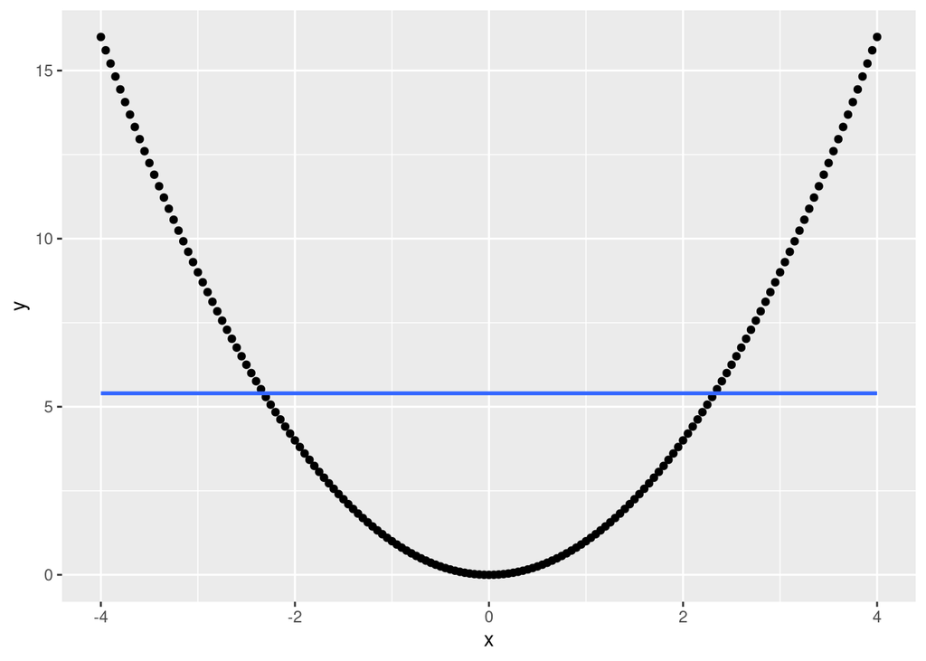

```r
df <- tibble(
              x = seq(-4, 4, 0.05),
              y = x^2
            )

df |>
  ggplot(aes(x = x, y = y)) +
  geom_point() +
  geom_smooth(method = "lm", se = FALSE)
```

The figure shows that the slope of the linear relationship is 0, so the correlation coefficient is also 0:

```r
cor(df$x, df$y)
```

```
[1] 1.627669e-16
```

##### **Question:** why is it not exactly 0?

But **we know for a fact that there is a non-linear relationship between the variables, because we defined the points using it.**

#### Important example 2 - correlation

If the linear relationship is not 0 (slope of the trend line $\neq$ 0), then $r_{xy} \neq 0$. But **there may be a stronger non-linear relationship**, as in the case of electricity demand.

For example, the correlation between electricity demand and temperature in the previous figure is only 0.26, but their **non-linear** relationship is much stronger (compare the linear model and the loess model fitted in the previous scatterplot).

```r
# Compute correlation coefficient
round(cor(vic_elec$Temperature, vic_elec$Demand), 2)
```

```
[1] 0.26
```

Remember that **a correlation coefficient of 0 does not mean the two variables are unrelated. It only means there is no linear relationship**.

Note: many sources on *statistics* and *data science* on the internet are unreliable:

- [Bad interpretation of correlation coefficient - ex 1](https://www.investopedia.com/ask/answers/032515/what-does-it-mean-if-correlation-coefficient-positive-negative-or-zero.asp)
- [Bad interpretation of correlation coefficient = 0 - ex 2](https://www.simplypsychology.org/correlation.html)

Other examples of variables with a correlation coefficient of 0:

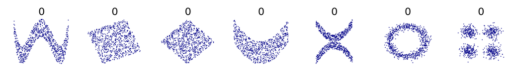

Examples of corr coefficient = 0 (Wikipedia)

#### Correlation coefficient vs. shape of the relationship

Remember also that **two variables may have a very similar correlation coefficient yet look very different**. The example below (ref [1]) shows scatterplots of different variables, all with a correlation coefficient of 0.82. The set of four images below is known as Anscombe’s quartet.

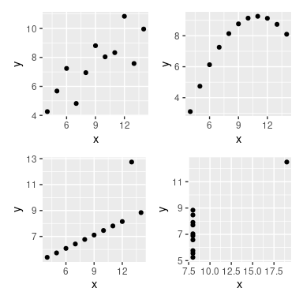

Examples of variables having the same correlation coefficient. From [1]

Finally, the animation below shows that, for a given correlation coefficient and a number $n$ of data points, there are infinitely many orderings of those points that produce the same coefficient. In other words, the correlation coefficient is relevant but tells us little about the distribution of the points.

[figure not shown]

Datasaurus - from ref. 3

All these examples show **how important it is to plot a scatterplot of the variables and not to rely only on the correlation coefficient**, which summarizes only their linear relationship.

## Several variables - scatterplot matrix

```r
visitors <- tourism |>
  # The rule from Session 2 was specifically about using group_by to aggregate over time,
  # which is what index_by() is for. Using group_by to aggregate across keys is fine and standard
  group_by(State) |>
  summarise(Trips = sum(Trips))

visitors
```

```
# A tsibble: 640 x 3 [1Q]
# Key:       State [8]
   State Quarter Trips
   <chr>   <qtr> <dbl>
 1 ACT   1998 Q1  551.
 2 ACT   1998 Q2  416.
 3 ACT   1998 Q3  436.
 4 ACT   1998 Q4  450.
 5 ACT   1999 Q1  379.
 6 ACT   1999 Q2  558.
 7 ACT   1999 Q3  449.
 8 ACT   1999 Q4  595.
 9 ACT   2000 Q1  600.
10 ACT   2000 Q2  557.
# ℹ 630 more rows
```

```r
# Check the distinct values of the State column
distinct(visitors, State)
```

```
# A tibble: 8 × 1
  State
  <chr>
1 ACT
2 New South Wales
3 Northern Territory
4 Queensland
5 South Australia
6 Tasmania
7 Victoria
8 Western Australia
```

```r
visitors |>
  pivot_wider(values_from=Trips, names_from=State)
```

```
# A tsibble: 80 x 9 [1Q]
   Quarter   ACT `New South Wales` `Northern Territory` Queensland
     <qtr> <dbl>             <dbl>                <dbl>      <dbl>
 1 1998 Q1  551.             8040.                 181.      4041.
 2 1998 Q2  416.             7166.                 314.      3968.
 3 1998 Q3  436.             6748.                 528.      4594.
 4 1998 Q4  450.             7282.                 248.      4203.
 5 1999 Q1  379.             7585.                 185.      4332.
 6 1999 Q2  558.             7054.                 366.      4824.
 7 1999 Q3  449.             6724.                 501.      5018.
 8 1999 Q4  595.             7136.                 248.      4350.
 9 2000 Q1  600.             7296.                 206.      4413.
10 2000 Q2  557.             6445.                 360.      4344.
# ℹ 70 more rows
# ℹ 4 more variables: `South Australia` <dbl>, Tasmania <dbl>, Victoria <dbl>,
#   `Western Australia` <dbl>
```

Too many combinations! It’s not practical to compare all these one by one. So use the GGally library instead: `ggpairs()` gives you the full matrix in one command: scatterplots below the diagonal, correlations above it, distributions on it (pick any pair and follow along rows and columns).

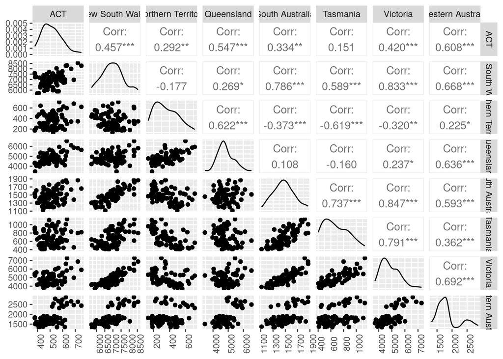

```r
visitors |>
  pivot_wider(values_from=Trips, names_from=State) |>
  GGally::ggpairs(columns = 2:9) +
  theme(axis.text.x = element_text(angle = 90))
```

We can add a **loess** line to the scatterplots to help identify non-linearities with the following code (with that, now we can see at a glance which pairs have curvature the correlation coefficient misses):

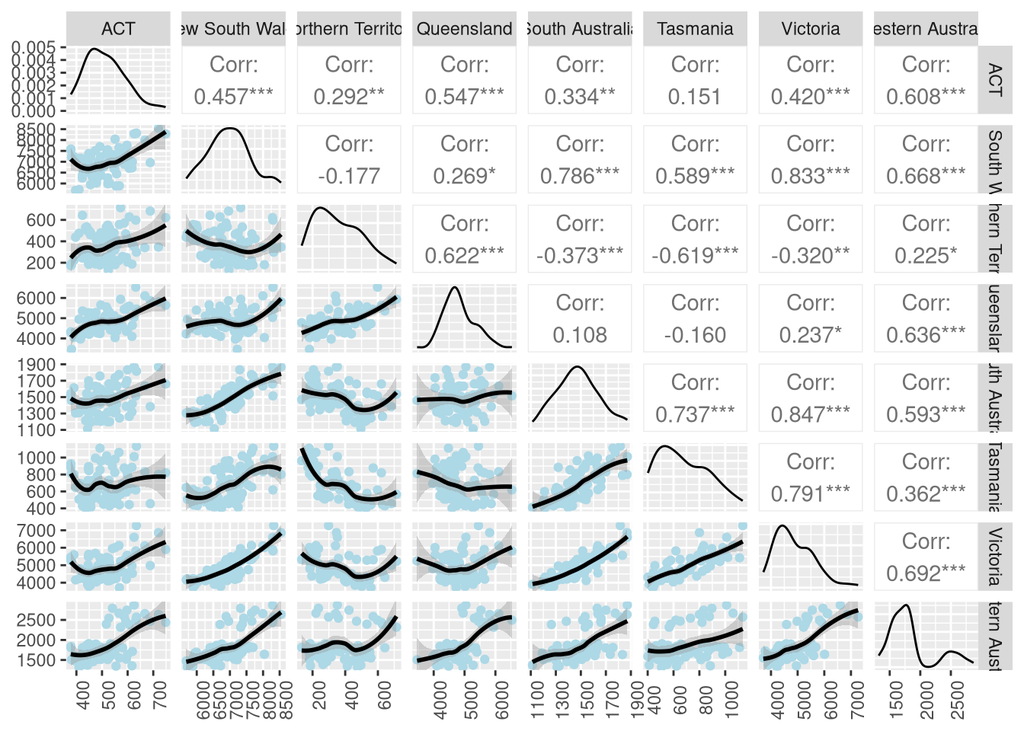

```r
visitors |>
  pivot_wider(values_from=Trips, names_from=State) |>
  GGally::ggpairs(columns = 2:9, lower = list(continuous = wrap("smooth_loess", color="lightblue"))) +
  theme(axis.text.x = element_text(angle = 90))
```

**Key takeaway:** read the scatterplots first and the coefficients second.

## Exercise: scatterplot matrix and lagged variables

The code below loads the dataset `soi_recruitment` from the `data/` folder at the repository root. This dataset contains two variables and is taken from reference 4.

- SOI: the Southern Oscillation Index for 453 months over 1950-1987. It is a standardized index based on the observed sea-level pressure (SLP) difference between Tahiti and Darwin, Australia, and measures the large-scale air-pressure fluctuations between the western and eastern tropical Pacific (the state of the Southern Oscillation) during El Niño and La Niña episodes. For more information, see [link](https://www.ncei.noaa.gov/access/monitoring/enso/soi).
- Recruitment: an index of the number of new fish, for 453 months over 1950-1987. Recruitment is loosely defined as an indicator of new members of a population. The data was gathered by Dr. Roy Mendelssohn, from the Pacific Environmental Fisheries Group.

```r
soi_recruitment <-
   read_csv("../../data/soi_recruitment.csv") |>
   mutate(ym = yearmonth(index)) |>
   select(ym, SOI, recruitment) |>
   as_tsibble(index = ym)

# Inspect result
soi_recruitment
```

### Lagged variables and their importance in time series

We will explore this concept further in later classes, but it is important to introduce it now.

Given a **variable** $x_t$, its lags correspond to **delayed versions of the variable**, with the number of the lag indicating the time delay:

- The first lag of a variable $x_t$ is written as $x_{t-1}$. At any point in time $t$, the value of $x_{t-1}$ is the value of $x_t$ one timestep ago.
- The second lag of a variable $x_t$ is written as $x_{t-2}$. At any point in time $t$, the value of $x_{t-2}$ is the value of $x_t$ two timesteps ago.
- …
- The n-th lag of a variable $x_t$ is written as $x_{t-n}$. At any point in time $t$, the value of $x_{t-n}$ is the value of $x_t$ $n$ timesteps ago.

**Lagged variables matter in time series** for two main reasons:

1. By studying the relationship between the lags {$x_{t-1}$, $x_{t-2}$, $\cdots$, $x_{t-n}$} and $x_t$, we can **see whether the variable** $x_t$ is related to its values from some timesteps ago.
2. By studying the relationship between the lags {$x_{t-1}$, $x_{t-2}$, $\cdots$, $x_{t-n}$} and a second variable $y_t$, we can **see whether** $y_t$ is related to past values of the variable x.
   - **A typical business case:** current sales might be related to marketing investment a few timesteps ago.

For example, the code below **computes the first 8 lags of the variable `SOI`:**

```r
# Compute desired lags
for (i in seq(1, 8)) {
  lag_name <- paste0("SOI_l", i)
  soi_recruitment[[lag_name]] = lag(soi_recruitment[["SOI"]], i)
}

# Reorder
soi_recruitment <-
  soi_recruitment |>
  select(ym, recruitment, everything())

# Inspect result.
soi_recruitment
```

```
# A tsibble: 453 x 11 [1M]
         ym recruitment    SOI SOI_l1 SOI_l2 SOI_l3 SOI_l4 SOI_l5 SOI_l6 SOI_l7
      <mth>       <dbl>  <dbl>  <dbl>  <dbl>  <dbl>  <dbl>  <dbl>  <dbl>  <dbl>
 1 1950 Jan        68.6  0.377 NA     NA     NA     NA     NA     NA     NA
 2 1950 Feb        68.6  0.246  0.377 NA     NA     NA     NA     NA     NA
 3 1950 Mar        68.6  0.311  0.246  0.377 NA     NA     NA     NA     NA
 4 1950 Apr        68.6  0.104  0.311  0.246  0.377 NA     NA     NA     NA
 5 1950 May        68.6 -0.016  0.104  0.311  0.246  0.377 NA     NA     NA
 6 1950 Jun        68.6  0.235 -0.016  0.104  0.311  0.246  0.377 NA     NA
 7 1950 Jul        59.2  0.137  0.235 -0.016  0.104  0.311  0.246  0.377 NA
 8 1950 Aug        48.7  0.191  0.137  0.235 -0.016  0.104  0.311  0.246  0.377
 9 1950 Sep        47.5 -0.016  0.191  0.137  0.235 -0.016  0.104  0.311  0.246
10 1950 Oct        50.9  0.29  -0.016  0.191  0.137  0.235 -0.016  0.104  0.311
# ℹ 443 more rows
# ℹ 1 more variable: SOI_l8 <dbl>
```

### Exercise: **generate the scatterplot matrix below**

**Question:** do you detect any non-linear relationship between recruitment and SOI or any of its lags (`SOI_l1` to `SOI_l8`) that the correlation coefficient does not capture?

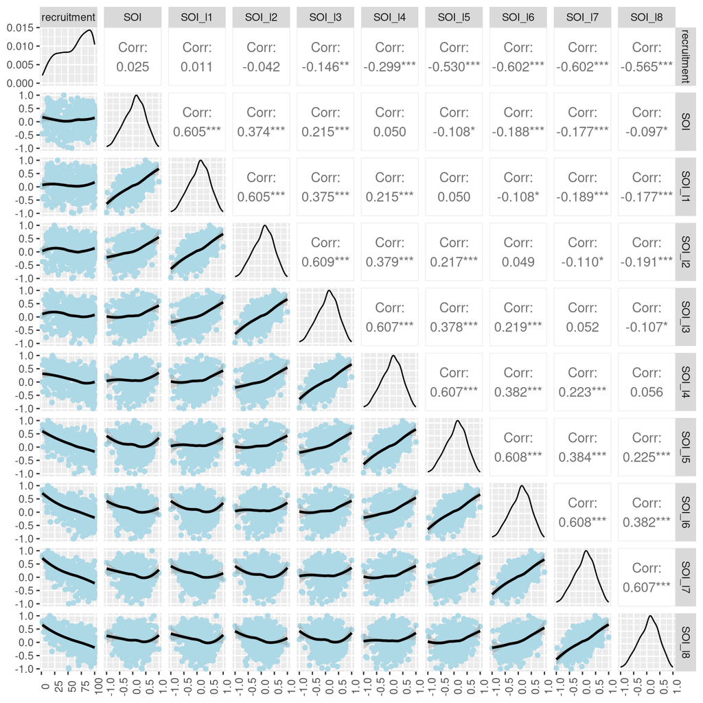

#### We’ll discuss potential solutions during the live session.

# Seasonal plots - gg_season

**Difference from a time plot:** the x-axis does not extend indefinitely over time, but only over the duration of a season. The time axis is limited to a single season. In most situations in this course, that season will be a year.

The period of a time series is always longer than its sampling interval.

- **Example 1:** with **quarterly data**, the natural seasonal period is the next calendar unit up, which is a year.
- **Example 2:** with **monthly data**, the natural seasonal period is the next calendar unit up: a quarter or a year. We will usually take a year for monthly data.
- **Example 3:** with **daily data**, multiple seasonal periods can be considered: week, month, year…
- **Example 4:** with **sub-daily data**, the day itself could be considered as a seasonal period…
- …

Let us return to the antidiabetic drug sales example in Australia. The `PBS` dataset contains monthly Medicare Australia prescription data. We keep the records for drugs in the `ATC2` category `"A10"` (antidiabetic drugs). For more information, run `?PBS` in the console.

```r
PBS |>
  filter(ATC2 == "A10") |>
  select(Month, Concession, Type, Cost) |>
  summarise(TotalC = sum(Cost)) |>

  # Comment on this assignment operator
  mutate(Cost = TotalC / 1e6) -> a10

a10
```

```
# A tsibble: 204 x 3 [1M]
      Month  TotalC  Cost
      <mth>   <dbl> <dbl>
 1 1991 Jul 3526591  3.53
 2 1991 Aug 3180891  3.18
 3 1991 Sep 3252221  3.25
 4 1991 Oct 3611003  3.61
 5 1991 Nov 3565869  3.57
 6 1991 Dec 4306371  4.31
 7 1992 Jan 5088335  5.09
 8 1992 Feb 2814520  2.81
 9 1992 Mar 2985811  2.99
10 1992 Apr 3204780  3.20
# ℹ 194 more rows
```

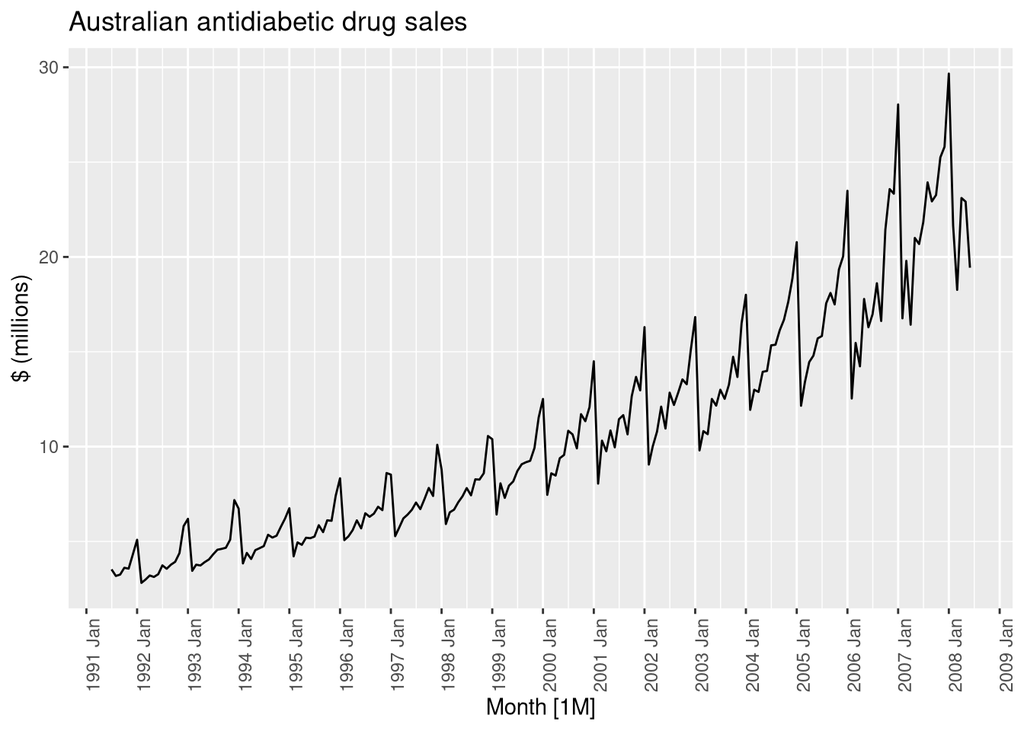

```r
# Recall the time plot
autoplot(a10, Cost) +
  labs(y = "$ (millions)",
       title = "Australian antidiabetic drug sales") +
  scale_x_yearmonth(breaks = "1 year") +
  theme(axis.text.x = element_text(angle = 90))
```

Here we have monthly data, so the natural period to consider is a year, which covers all the calendar variations and is a higher order than the data. The time plot seems to confirm this. We will cover seasonality and periods in more detail in later lessons, through the concept of *autocorrelation*.

Now let us produce a seasonal plot using `gg_season`.

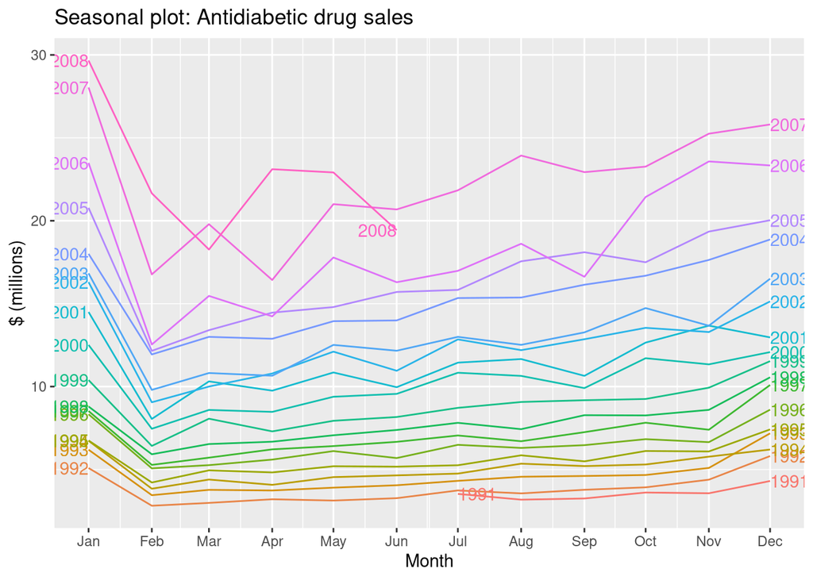

```r
a10 |>
  gg_season(Cost, labels = "both") + # Labels -> "both", "right", "left"
  labs(y = "$ (millions)",
       title = "Seasonal plot: Antidiabetic drug sales")
```

As you can see, the x-axis is limited to the duration of a year. Each year is then plotted and color-coded with a gradient scale. The plot shows jumps in the general level of the series each year, a first decline from January to February, and a recovery through the rest of the year (why? ASK YOUR STAKEHOLDERS! You spotted the pattern and know what to ask more precisely).

(The reason is that Australian patients stockpile prescriptions before the subsidy year resets).

## Multiple seasonal periods

The `vic_elec` dataset, loaded with fpp3, contains **half-hourly electricity demand** for the state of Victoria (Australia) for **three years**. Because the **data is sampled every half hour, it shows multiple seasonal patterns**:

- Daily pattern (period 48)
- Weekly pattern
- Yearly pattern…

### Daily period example

Let us check when the data begins and ends. One way to do this is:

```r
head(vic_elec)
```

```
# A tsibble: 6 x 5 [30m] <Australia/Melbourne>
  Time                Demand Temperature Date       Holiday
  <dttm>               <dbl>       <dbl> <date>     <lgl>
1 2012-01-01 00:00:00  4383.        21.4 2012-01-01 TRUE
2 2012-01-01 00:30:00  4263.        21.0 2012-01-01 TRUE
3 2012-01-01 01:00:00  4049.        20.7 2012-01-01 TRUE
4 2012-01-01 01:30:00  3878.        20.6 2012-01-01 TRUE
5 2012-01-01 02:00:00  4036.        20.4 2012-01-01 TRUE
6 2012-01-01 02:30:00  3866.        20.2 2012-01-01 TRUE
```

```r
tail(vic_elec)
```

```
# A tsibble: 6 x 5 [30m] <Australia/Melbourne>
  Time                Demand Temperature Date       Holiday
  <dttm>               <dbl>       <dbl> <date>     <lgl>
1 2014-12-31 21:00:00  3928.        20.3 2014-12-31 FALSE
2 2014-12-31 21:30:00  3873.        19   2014-12-31 FALSE
3 2014-12-31 22:00:00  3792.        18.5 2014-12-31 FALSE
4 2014-12-31 22:30:00  3725.        17.7 2014-12-31 FALSE
5 2014-12-31 23:00:00  3762.        17.3 2014-12-31 FALSE
6 2014-12-31 23:30:00  3809.        17.1 2014-12-31 FALSE
```

The dataset contains measurements from 2012, 2013 and 2014 (three years).

You can adjust the seasonal period used by `gg_season` (when the data supports it) with the `period` argument. For example, a daily period:

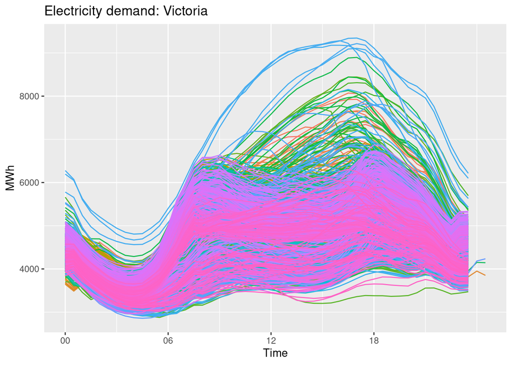

```r
vic_elec |> gg_season(Demand, period = "day") +
  theme(legend.position = "none") +
  labs(y="MWh", title="Electricity demand: Victoria")
```

1. **Question:** what does each line represent in the data?
2. **Question:** how many data points do we have?
3. **Question:** how many lines do we have in our graph?
4. **Question:** how many data points per line do we have?

#### We’ll discuss potential solutions during the live session.

```r
1. Each line represents the demand in a specific day.
2. 3 * 365 * 24 * 2 = 52,560 # 3 years and 2 * 24 because the data is half-hourly
3. 3 * 365 = 1,095
4. 52,560 / 1,095 = 24 * 2 = 48 (48 half hours in a day)
```

### Weekly period example

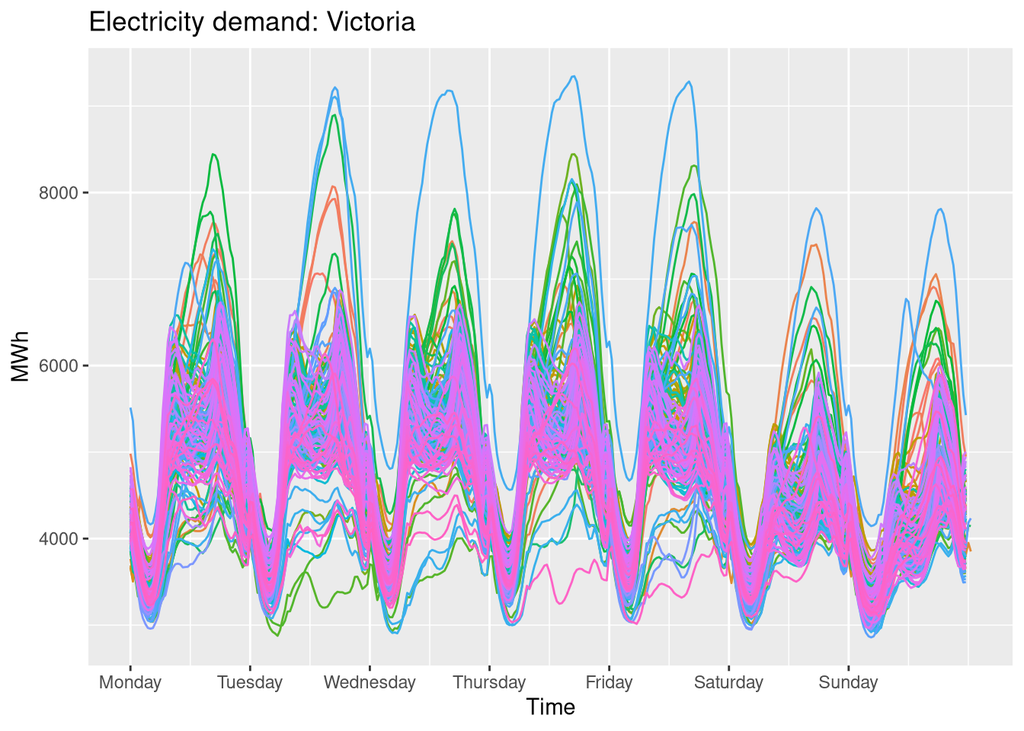

```r
vic_elec |> gg_season(Demand, period = "week") +
  theme(legend.position = "none") +
  labs(y="MWh", title="Electricity demand: Victoria")
```

1. **Question:** what does each line represent in the data?
2. **Question:** how many weeks are there in a year?
3. **Question:** how many lines do we have in this data?
4. **Question:** how many data points does each line have?

#### We’ll discuss potential solutions during the live session.

```r
1. Electricity consumption over a specific week
2. 365.25 / 7 = 52.18 on average (one leap year every 4 years, approximately)
3. Approximately 52 * 3
4. 7 * 24 * 2 = 336
```

### Yearly period example

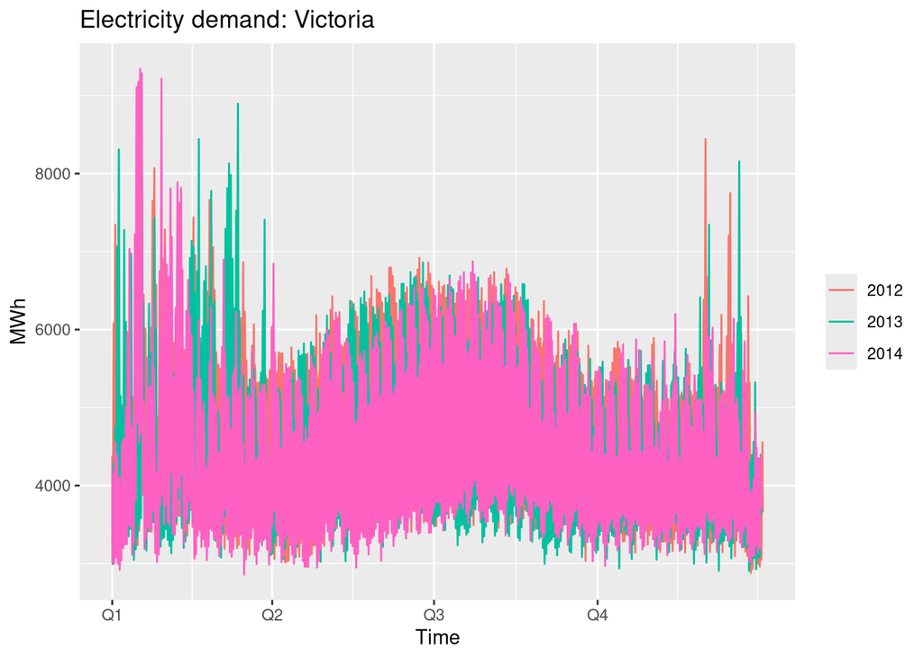

```r
vic_elec |> gg_season(Demand, period = "year") +
  labs(y="MWh", title="Electricity demand: Victoria")
```

1. **Question:** what does each line represent?
2. **Question:** how many data points do we have per line?
3. **Question:** propose an alternative, less noisy way to represent the data:

#### We’ll discuss potential solutions during the live session.

```r
* Each line represents the electricity consumption for a specific year
* 365 * 24 * 2 = 17520
* For example: aggregate by month using `index_by`, with a maximum, minimum and average value.
```

# Seasonal subseries plot

## Exercise seasonal plots

The `aus_arrivals` dataset (loaded with the `fpp3` package) contains quarterly international arrivals (in thousands) to Australia from Japan, New Zealand, the UK and the US.

Create:

- A time plot of the arrivals using `autoplot()` (one curve per country of origin)
- A seasonal plot using `gg_season()` (the structure of the data produces one graph per country of origin)
- A `gg_subseries()` plot showing the evolution of quarterly arrivals per country over the period considered (see the next section on `gg_subseries()`)

```r
aus_arrivals
```

```
# A tsibble: 508 x 3 [1Q]
# Key:       Origin [4]
   Quarter Origin Arrivals
     <qtr> <chr>     <int>
 1 1981 Q1 Japan     14763
 2 1981 Q2 Japan      9321
 3 1981 Q3 Japan     10166
 4 1981 Q4 Japan     19509
 5 1982 Q1 Japan     17117
 6 1982 Q2 Japan     10617
 7 1982 Q3 Japan     11737
 8 1982 Q4 Japan     20961
 9 1983 Q1 Japan     20671
10 1983 Q2 Japan     12235
# ℹ 498 more rows
```

### We’ll discuss potential solutions during the live session.

# Seasonal subseries plots: `gg_subseries()`

An alternative plot emphasizes seasonal patterns. The data for each season are collected into separate mini time plots, one per seasonal division. This is best understood through examples:

## Example with monthly data

```r
a10
```

```
# A tsibble: 204 x 3 [1M]
      Month  TotalC  Cost
      <mth>   <dbl> <dbl>
 1 1991 Jul 3526591  3.53
 2 1991 Aug 3180891  3.18
 3 1991 Sep 3252221  3.25
 4 1991 Oct 3611003  3.61
 5 1991 Nov 3565869  3.57
 6 1991 Dec 4306371  4.31
 7 1992 Jan 5088335  5.09
 8 1992 Feb 2814520  2.81
 9 1992 Mar 2985811  2.99
10 1992 Apr 3204780  3.20
# ℹ 194 more rows
```

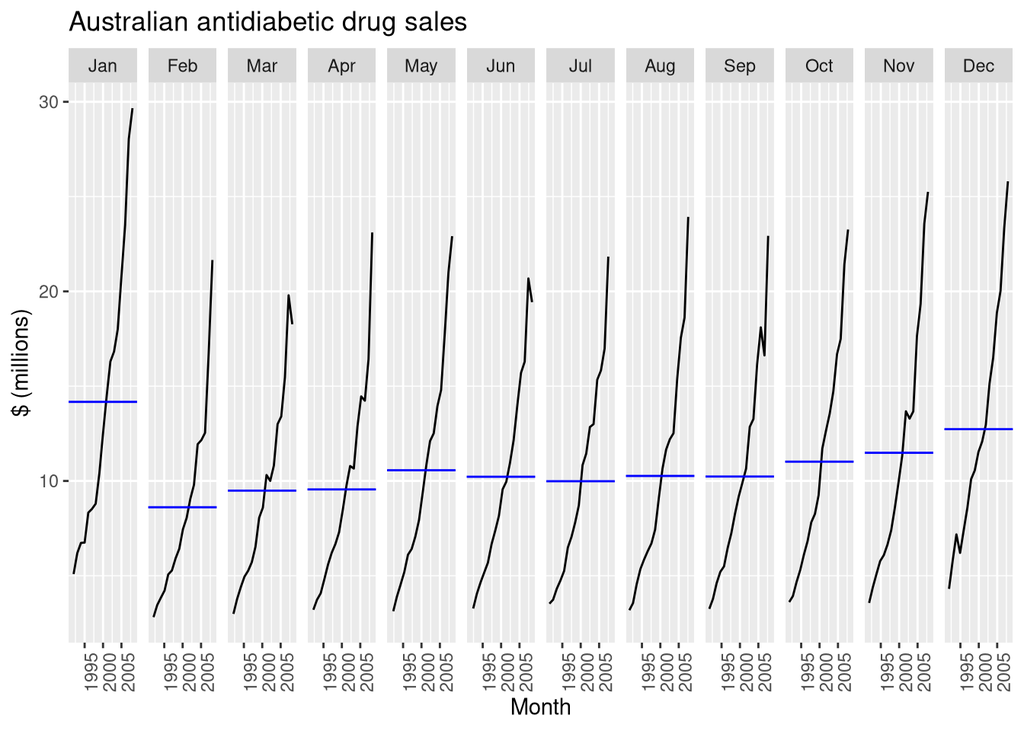

```r
a10 |>
  gg_subseries(Cost) +
  labs(
    y = "$ (millions)",
    title = "Australian antidiabetic drug sales",
  )
```

Why does it produce this output?

Because of the date format: Year-Month.

- The **smallest time unit in the index** is taken as **the unit in which the period is split**. In this case, **month**.
- The period considered is the largest period included in the time index. In this case, **year**.

**KEY TAKEAWAY: PREDICT BEFORE YOU RUN! (see below)**

As you can see, **specifying “year” as the period is simply redundant in this case.**

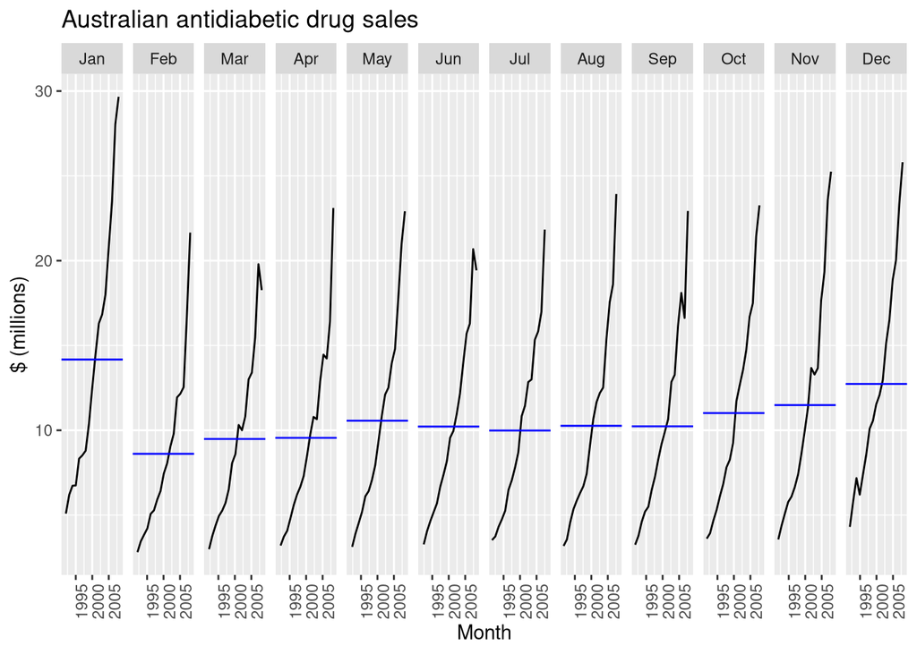

```r
a10 |>
  gg_subseries(Cost, period = "year") +
  labs(
    y = "$ (millions)",
    title = "Australian antidiabetic drug sales",
  )
```

**Question:** what will the output of this code be?

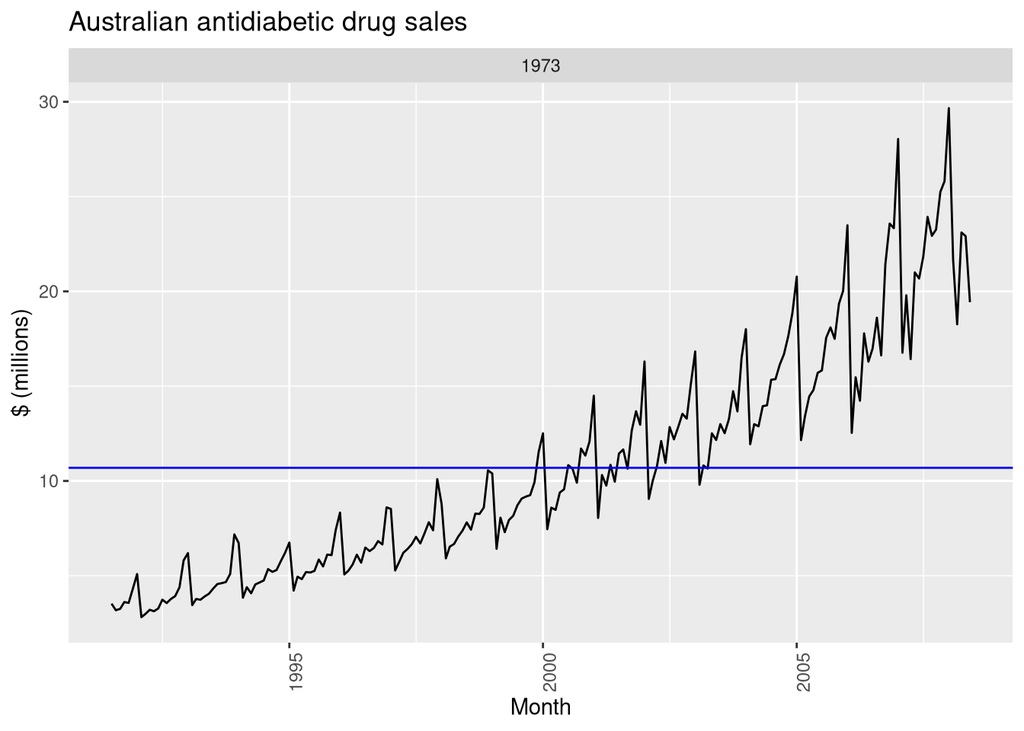

```r
a10 |>
  gg_subseries(Cost, period = "month") +
  labs(
    y = "$ (millions)",
    title = "Australian antidiabetic drug sales",
  )
```

```r
It gives the same output as a time plot, because we set the smallest time unit in the index (month) as the period. Since the data is monthly, a month cannot be split further.
```

**Question:** what is the output of this code?

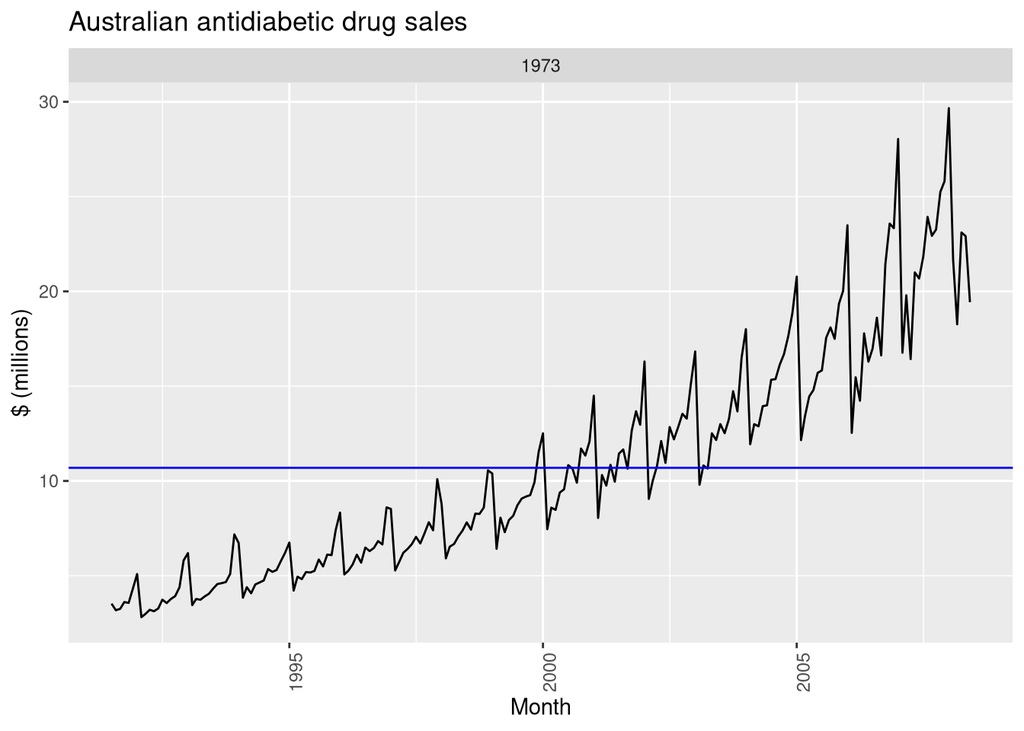

```r
a10 |>
  gg_subseries(Cost, period = "day") +
  labs(
    y = "$ (millions)",
    title = "Australian antidiabetic drug sales",
  )
```

```r
Same output as before. The smallest time unit in the index is "month",
which is greater than "day", so it is pointless to set day as the period.
```

## Example with sub-daily data

Note: this example is not mathematically important, but it helps you understand the logic behind sub-seasonal plots.

```r
head(vic_elec)
```

```
# A tsibble: 6 x 5 [30m] <Australia/Melbourne>
  Time                Demand Temperature Date       Holiday
  <dttm>               <dbl>       <dbl> <date>     <lgl>
1 2012-01-01 00:00:00  4383.        21.4 2012-01-01 TRUE
2 2012-01-01 00:30:00  4263.        21.0 2012-01-01 TRUE
3 2012-01-01 01:00:00  4049.        20.7 2012-01-01 TRUE
4 2012-01-01 01:30:00  3878.        20.6 2012-01-01 TRUE
5 2012-01-01 02:00:00  4036.        20.4 2012-01-01 TRUE
6 2012-01-01 02:30:00  3866.        20.2 2012-01-01 TRUE
```

```r
tail(vic_elec)
```

```
# A tsibble: 6 x 5 [30m] <Australia/Melbourne>
  Time                Demand Temperature Date       Holiday
  <dttm>               <dbl>       <dbl> <date>     <lgl>
1 2014-12-31 21:00:00  3928.        20.3 2014-12-31 FALSE
2 2014-12-31 21:30:00  3873.        19   2014-12-31 FALSE
3 2014-12-31 22:00:00  3792.        18.5 2014-12-31 FALSE
4 2014-12-31 22:30:00  3725.        17.7 2014-12-31 FALSE
5 2014-12-31 23:00:00  3762.        17.3 2014-12-31 FALSE
6 2014-12-31 23:30:00  3809.        17.1 2014-12-31 FALSE
```

**Question:** what would the output of this code be? **Do not run this cell. It might crash your computer.**

```r
stop("This would create 17,520 subseries panels (365 x 24 x 2). Remove this guard only if you understand the risk.")

vic_elec |>
  gg_subseries(Demand) +
  labs(
    y = "Demand [MW]",
    title = "Half-hourly energy demand in the state of Victoria",
  )
```

It would take **the largest time unit in the index** (year) and split it by the **smallest time unit in the index** (half an hour). **Since there are 365 * 24 * 2 = 17520 half-hours in a year, it would create 17520 graphs.** This would be useless, unreadable, and would probably crash your computer.

**Takeaway:** be careful when using `gg_subseries()` with sub-daily data. Predict before you run it.

A first option is to set **period = “day”**. This is a natural first choice for sub-daily data, because a day is the next time unit up.

**Question:** what is the output of this code?

```r
vic_elec |>
  gg_subseries(Demand, period = "day") +
  labs(
    y = "[MW]",
    title = "Total electricity demand for Victoria, Australia"
  )

# Necessary to explore the output given the density of the data
ggsave("subseasonal_demand_hourly_PeriodDay.svg", width = 30, height = 5)
```

```r
48 graphs. The period = "day" divided by the smallest time unit (30 mins)

See the output in the separate file "subseasonal_demand_hourly_PeriodDay.svg".

Another option is to aggregate by month (see the next code snippet).
```

**Question:** what is the output of this code?

```r
vic_elec_m <- vic_elec |>
  index_by(month = yearmonth(Time)) |>
  summarise(
    avg_demand = mean(Demand)
  )

vic_elec_m |>
  gg_subseries(avg_demand, period = "year") +
  labs(
    y = "[MW]",
    title = "Total electricity demand for Victoria, Australia"
  )
```

**Question:** what is the output of this code?

```r
# We could also aggregate by quarter
vic_elec_q <- vic_elec |>
  index_by(quarter = yearquarter(Time)) |>
  summarise(
    avg_demand = mean(Demand)
  )

vic_elec_q |>
  gg_subseries(avg_demand, period = "year") +
  labs(
    y = "[MW]",
    title = "Total electricity demand for Victoria, Australia"
  )
```

So, the number of panels is set by the ratio between the period and the smallest unit in the index. If that ratio is 12, you get 12 panels (monthly data, yearly period). If it’s 48, you get 48 panels (half-hourly data, daily period). If it’s 17,520, you get a crash. The period argument lets you override the default (largest unit in the index), but you can never get more panels than the index resolution allows.

## Exercise - subseries plot

1. Aggregate the `vic_elec` data to daily data, computing the average demand for each day using `index_by()` + `summarise()` with `mean()`.
2. Create a `gg_subseries()` plot with one graph for each day of the month, plotting the values for each day across each month, **only for 2012**.

**See the expected output in the separate file** *subseasonal_demand_daily_PeriodMonth.svg*.

## Example with daily data

**Question:** what would the output of this code be?

```r
vic_elec_d <- vic_elec |>

  index_by(day = as_date(Time)) |>

  summarise(
    avg_demand = mean(Demand)
  )

# Filter values for 2012
filter(vic_elec_d, year(day) == 2012) |>

  # Create the gg_subseries plot
  gg_subseries(avg_demand, period = "year") +
  labs(
    y = "[MW]",
    title = "Total electricity demand for Victoria, Australia"
  )

ggsave("subseasonal_demand_daily_PeriodYear.svg", width = 40, height = 5)
```